# 1406

Valentina Nauchi

2024-06-14

```r
setwd("C:/Trabajo grupal Tucaloza y Valentini")
```

#Exportamos la data

```r
library(rio)
data1 = import("Latinobarometro2023.rdata")
```

```r
data1$idenpa=as.factor(data1$idenpa)
data1$idenpa=factor(data1$idenpa,
                levels = levels(data1$idenpa),
                labels = c("Argentina", "Bolivia", "Brasil", "Colombia", "Costa Rica" , "Chile" , "Ecuador", "El Salvador", "Guatemala", "Honduras", "México", "Nicaragua", "Panamá", "Paraguay", "Perú", "Uruguay", "Venezuela"),
                ordered = F)
```

Filtramos para tener solamente los datos de PERÚ

```r
library(dplyr)
peru <- data1 %>%
filter(idenpa=="Perú")
```

```r
names(peru)=gsub(pattern = "NUMENTRE",
replacement = "NumEntre",x = names(peru))
```

Ahora: Renombramos las variables y nos quedamos con los datos de nuestro interés

#VARIABLES INDEPENDIENTES Satisfacción con la democracia

```r
names(peru)=gsub(pattern = "P11STGBS.A",
                           replacement = "satis_dem",
                           x = names(peru))
```

```r
table(peru$satis_dem)
```

```
##
##  -2  -1   1   2   3   4
##   4  12  46  49 577 512
```

```r
library(dplyr)
peru = peru %>%
  filter(satis_dem %in% c(1,2,3,4))
```

```r
table(peru$satis_dem)
```

```
##
##   1   2   3   4
##  46  49 577 512
```

Creencias

```r
names(peru)=gsub(pattern = "P10STGB",
                           replacement = "creencias",
                           x = names(peru))
```

```r
library(dplyr)
peru = peru %>%
  filter(creenciasS %in% c(1,2,3))
```

#VARIABLES DE CONTROL #ETNIA

```r
names(peru)=gsub(pattern = "S7",
                           replacement = "etnia",
                           x = names(peru))
```

```r
library(dplyr)
peru = peru %>%
  filter(etnia %in% c(2,3,4,6))
table(peru$etnia)
```

```
##
##   2   3   4   6
##  30  80 857  61
```

#CLASE SOCIAL - ESTRATO

```r
names(peru)=gsub(pattern = "S2",
                           replacement = "estrato",
                           x = names(peru))
```

```r
library(dplyr)
peru = peru %>%
  filter(estrato %in% c(1,2,3,4,5))
table(peru$estrato)
```

```
##
##   1   2   3   4   5
##  22  58 428 332 171
```

#PARTIDO POLITICO - FAMPART #En el caso de esta variable, al tener muchas categorías lo que estamos haciendo es separar los datos en “Si se identidifica con un partido político” = 1, “No se identifica con ningún partido político” = 0

```r
names(peru)=gsub(pattern = "fampart",
                           replacement = "partido_pol",
                           x = names(peru))
```

```r
table(peru$partido_pol)
```

```
##
##   0  20  30  40  50  60  70  80  98
## 821  15   8  34  29  89  11   2   2
```

```r
library(dplyr)
peru = peru %>%
  filter(partido_pol %in% c(0,20,30,40,50,60,70,80,98))
```

```r
table(peru$partido_pol)
```

```
##
##   0  20  30  40  50  60  70  80  98
## 821  15   8  34  29  89  11   2   2
```

Ya que esta variable tiene muchas categorías, haremos una condición: Si pertene a un partido político será 1 de lo contrario será 0

```r
peru$partido_pol <- ifelse(peru$partido_pol != 0, 1, 0)
table(peru$partido_pol)
```

```
##
##   0   1
## 821 190
```

#VARIABLE DEPENDIENTE - CONFIANZA EN LAS INSTITUCIONES

```r
names(peru)=gsub(pattern = "P13ST.D",
                           replacement = "Congreso",
                           x = names(peru))
```

```r
names(peru)=gsub(pattern = "P13ST.E",
                           replacement = "Gobierno",
                           x = names(peru))
```

```r
names(peru)=gsub(pattern = "P13ST.G",
                           replacement = "Partidos_Politicos",
                           x = names(peru))
```

```r
names(peru)=gsub(pattern = "P13ST.I",
                           replacement = "Presidente",
                           x = names(peru))
```

#DATOS PERDIDOS

```r
total_na <- sum(is.na(peru))
print(paste("Total de valores NA:", total_na))
```

```
## [1] "Total de valores NA: 0"
```

```r
table(peru$Congreso)
```

```
##
##  -2   1   2   3   4
##   1  11  42 248 709
```

```r
library(dplyr)
peru = peru %>%
  filter(Congreso %in% c(1,2,3,4))
table(peru$Congreso)
```

```
##
##   1   2   3   4
##  11  42 248 709
```

```r
table(peru$Gobierno)
```

```
##
##  -1   1   2   3   4
##   1  16  80 298 615
```

```r
library(dplyr)
peru = peru %>%
  filter(Gobierno %in% c(1,2,3,4))
table(peru$Gobierno)
```

```
##
##   1   2   3   4
##  16  80 298 615
```

```r
table(peru$Partidos_Politicos)
```

```
##
##  -1   1   2   3   4
##   1  19  61 266 662
```

```r
library(dplyr)
peru = peru %>%
  filter(Partidos_Politicos %in% c(1,2,3,4))
table(peru$Partidos_Politicos)
```

```
##
##   1   2   3   4
##  19  61 266 662
```

```r
table(peru$Presidente)
```

```
##
##  -1   1   2   3   4
##   2  17 110 266 613
```

```r
library(dplyr)
peru = peru %>%
  filter(Presidente %in% c(1,2,3,4))
table(peru$Presidente)
```

```
##
##   1   2   3   4
##  17 110 266 613
```

```r
library(writexl)

MIPAIS <- peru [,c("numentre","satis_dem", "creenciasS", "etnia", "estrato", "partido_pol", "Congreso", "Gobierno", "Partidos_Politicos", "Presidente")]
```

#EFA 2

```r
names(MIPAIS)
```

```
##  [1] "numentre"           "satis_dem"          "creenciasS"
##  [4] "etnia"              "estrato"            "partido_pol"
##  [7] "Congreso"           "Gobierno"           "Partidos_Politicos"
## [10] "Presidente"
```

```r
dontselect=c("numentre","satis_dem","creenciasS","etnia","estrato", "partido_pol")
select=setdiff(names(MIPAIS),dontselect)
DF=MIPAIS[,select]

# usaremos:
library(magrittr)
head(DF,10)%>%
    rmarkdown::paged_table()
```

|  | Congreso | Gobierno | Partidos_Politicos | Presidente |
| --- | --- | --- | --- | --- |
| 15605 | 3 | 3 | 3 | 3 |
| 15606 | 3 | 3 | 3 | 3 |
| 15607 | 4 | 4 | 4 | 4 |
| 15609 | 4 | 4 | 4 | 4 |
| 15610 | 4 | 4 | 4 | 4 |
| 15611 | 4 | 4 | 4 | 4 |
| 15612 | 3 | 3 | 3 | 3 |
| 15613 | 3 | 3 | 2 | 2 |
| 15614 | 3 | 3 | 3 | 3 |
| 15615 | 4 | 4 | 4 | 4 |

#Calculemos las correlaciones entre todas las variables

```r
DF$Congreso= as.numeric(DF$Congreso)
DF$Gobierno= as.numeric(DF$Gobierno)
DF$Partidos_Politicos= as.numeric(DF$Partidos_Politicos)
DF$Presidente= as.numeric(DF$Presidente)
```

```r
library(polycor)
```

```r
corMatrix=polycor::hetcor(DF)$correlations
```

```r
round(corMatrix,2)
```

```
##                    Congreso Gobierno Partidos_Politicos Presidente
## Congreso               1.00     0.59               0.46       0.45
## Gobierno               0.59     1.00               0.45       0.64
## Partidos_Politicos     0.46     0.45               1.00       0.37
## Presidente             0.45     0.64               0.37       1.00
```

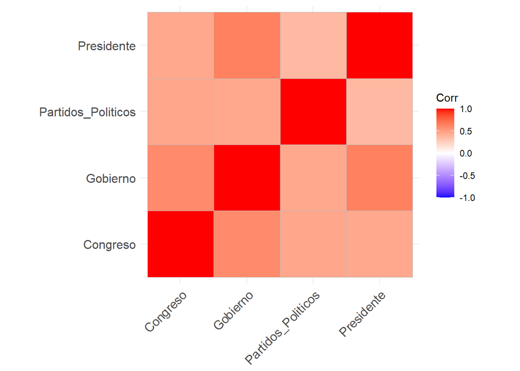

```r
library(ggcorrplot)
ggcorrplot(corMatrix)
```

```r
library(psych)
psych::KMO(corMatrix)
```

```
## Kaiser-Meyer-Olkin factor adequacy
## Call: psych::KMO(r = corMatrix)
## Overall MSA =  0.75
## MSA for each item =
##           Congreso           Gobierno Partidos_Politicos         Presidente
##               0.78               0.70               0.84               0.74
```

```r
cortest.bartlett(corMatrix,n=nrow(DF))$p.value>0.05
```

```
## [1] FALSE
```

```r
library(matrixcalc)

is.singular.matrix(corMatrix)
```

```
## [1] FALSE
```

```r
fa.parallel(DF, fa = 'fa',correct = T,plot = F)
```

```
## Parallel analysis suggests that the number of factors =  2  and the number of components =  NA
```

```r
library(GPArotation)
resfa <- fa(DF,
            nfactors = 1,
            cor = 'mixed',
            rotate = "varimax", #oblimin?
            fm="minres")
print(resfa$loadings)
```

```
##
## Loadings:
##                    MR1
## Congreso           0.811
## Gobierno           0.923
## Partidos_Politicos 0.676
## Presidente         0.773
##
##                  MR1
## SS loadings    2.562
## Proportion Var 0.641
```

```r
sort(resfa$communality)
```

```
## Partidos_Politicos         Presidente           Congreso           Gobierno
##          0.4568818          0.5971540          0.6571722          0.8510519
```

```r
regresFactors=as.data.frame(resfa$scores)%>%head()
```

```r
MIPAIS$confianza_instituciones <- resfa$scores

head(MIPAIS)
```

```
##       numentre satis_dem creenciasS etnia estrato partido_pol Congreso Gobierno
## 15605      541         3          1     4       3           0        3        3
## 15606      904         3          1     4       3           1        3        3
## 15607      853         4          2     4       5           0        4        4
## 15609       32         4          1     3       4           0        4        4
## 15610      854         4          1     4       5           1        4        4
## 15611       94         4          1     4       3           0        4        4
##       Partidos_Politicos Presidente        MR1
## 15605                  3          3 -0.9947508
## 15606                  3          3 -0.9947508
## 15607                  4          4  0.8399561
## 15609                  4          4  0.8399561
## 15610                  4          4  0.8399561
## 15611                  4          4  0.8399561
```

```r
names(MIPAIS)=gsub(pattern = "confianza_instituciones",
                           replacement = "conf_inst",
                           x = names(MIPAIS))
```

#Rescale confianza en las instituciones

```r
range(MIPAIS$conf_inst, na.rm = TRUE)
```

```
## [1] -4.6641645  0.8399561
```

```r
MIPAIS$confianza <- cut(
  MIPAIS$conf_inst,
  breaks = 10,                    # Dividir en 10 categorías
  labels = 1:10,                  # Etiquetar las categorías del 1 al 10
  include.lowest = TRUE           # Incluir el valor mínimo en la primera categoría
)

# Convertir a numérica si es necesario
MIPAIS$confianza <- as.numeric(as.character(MIPAIS$confianza))

# Verificar los primeros registros para asegurarse de que la recategorización funcionó
head(MIPAIS[, c("conf_inst", "confianza")])
```

```
##              MR1 confianza
## 15605 -0.9947508         7
## 15606 -0.9947508         7
## 15607  0.8399561        10
## 15609  0.8399561        10
## 15610  0.8399561        10
## 15611  0.8399561        10
```

```r
table(MIPAIS$confianza)
```

```
##
##   1   2   3   4   5   6   7   8   9  10
##   5   1   5  22  26  37 121 105 151 533
```

#Crear una columna que indique: Si el puntaje es >=7 sí confia (1) de lo contrario no confía (0)

```r
MIPAIS$confia <- ifelse(MIPAIS$confianza >= 7, "1", "0")

head(MIPAIS[, c("confianza", "confia")])
```

```
##       confianza confia
## 15605         7      1
## 15606         7      1
## 15607        10      1
## 15609        10      1
## 15610        10      1
## 15611        10      1
```

library(writexl) write_xlsx(MIPAIS, “MiPais-Completo.xlsx”)

```r
library(writexl)

DATAFINAL <- MIPAIS [,c("numentre","satis_dem", "creenciasS", "etnia", "estrato", "partido_pol", "confianza", "confia")]
```

Descargamos nuestra data final para realizar nuestras regresiones

```r
write_xlsx(DATAFINAL, "perufinal.xlsx")
```

#REGRESIÓN LINEAL MULTIPLE

```r
library(rio)
PERU= import("perufinal.xlsx")
```

```r
str(PERU)
```

```
## 'data.frame':    1006 obs. of  8 variables:
##  $ numentre   : num  541 904 853 32 854 ...
##  $ satis_dem  : num  3 3 4 4 4 4 3 3 2 4 ...
##  $ creenciasS : num  1 1 2 1 1 1 2 3 1 1 ...
##  $ etnia      : num  4 4 4 3 4 4 3 4 4 4 ...
##  $ estrato    : num  3 3 5 4 5 3 4 4 3 4 ...
##  $ partido_pol: num  0 1 0 0 1 0 0 0 0 1 ...
##  $ confianza  : num  7 7 10 10 10 10 7 6 7 10 ...
##  $ confia     : chr  "1" "1" "1" "1" ...
```

#Hacemos un summary de nuestra variable de interes “Confianza”

```r
summary(PERU$confianza)
```

```
##    Min. 1st Qu.  Median    Mean 3rd Qu.    Max.
##   1.000   8.000  10.000   8.785  10.000  10.000
```

```r
library(DescTools)
allStats=c(summary(PERU$confianza),
  sd=sd(PERU$confianza),
  skew=Skew(PERU$confianza),
  kurt=Kurt(PERU$confianza),
  cv=CoefVar(PERU$confianza))
allStats
```

```
##       Min.    1st Qu.     Median       Mean    3rd Qu.       Max.         sd
##  1.0000000  8.0000000 10.0000000  8.7852883 10.0000000 10.0000000  1.7056016
##       skew       kurt         cv
## -1.6113072  2.5934197  0.1941429
```

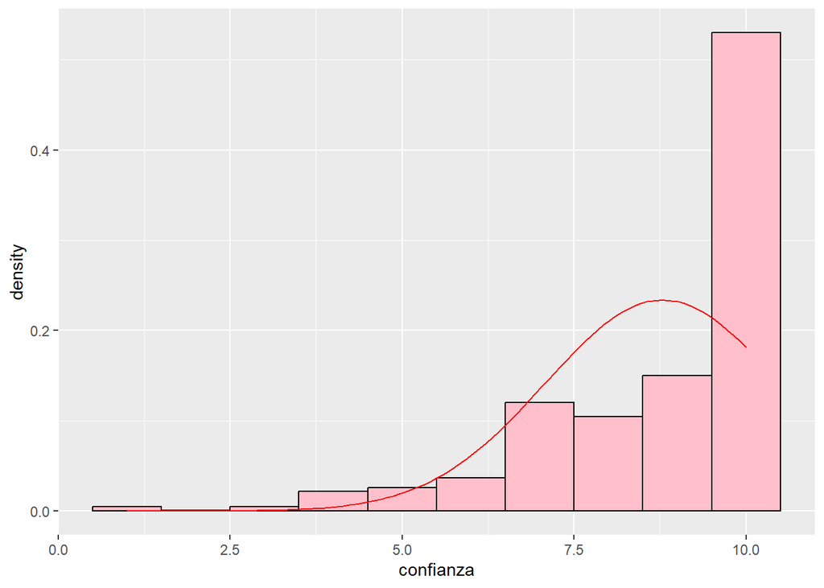

```r
library(ggplot2)

base=ggplot(data=PERU,
            aes(x=confianza))
histogram= base + geom_histogram(aes(y = after_stat(density)),
                 colour = 1, fill = "pink",bins=10) +
    stat_function(fun = dnorm,
                  args = list(mean = allStats['Mean'],
                              sd = allStats['sd']),col='red')

histogram
```

#PARA CORRELACIÓN, VERIFICAMOS QUE NUESTRAS VARIABLES SEAN NUMERICAS

#GRAFICOS DE CORRELACIÓN CON ANOVA

Tenemos 1 variable dependiente que es CONFIANZA EN LAS INSTITUCIOENS, y las dos variables independientes son CATEGORICAS, CREENCIAS Y SATIS_DEM. En ese caso utilizaremos, un prueba de ANOVA para ver la diferencia de medias entre los grupos.

```r
# ANOVA para satisfacción con la democracia
anova_satis_dem <- aov(confianza ~ satis_dem, data = PERU)
summary(anova_satis_dem)
```

```
##               Df Sum Sq Mean Sq F value Pr(>F)
## satis_dem      1  389.6   389.6   154.4 <2e-16 ***
## Residuals   1004 2534.0     2.5
## ---
## Signif. codes:  0 '***' 0.001 '**' 0.01 '*' 0.05 '.' 0.1 ' ' 1
```

```r
anova_creenciasS <- aov(confianza ~ creenciasS, data = PERU)
summary(anova_creenciasS)
```

```
##               Df Sum Sq Mean Sq F value   Pr(>F)
## creenciasS     1   35.2   35.20   12.24 0.000489 ***
## Residuals   1004 2888.4    2.88
## ---
## Signif. codes:  0 '***' 0.001 '**' 0.01 '*' 0.05 '.' 0.1 ' ' 1
```

#PARA GRAFICOS

```r
# Calcular las medias y errores estándar
df_summary_satis <- PERU %>%
  group_by(satis_dem) %>%
  summarise(
    mean_confianza = mean(confianza, na.rm = TRUE),
    se_confianza = sd(confianza, na.rm = TRUE) / sqrt(n())
  )

df_summary_creencias <- PERU %>%
  group_by(creenciasS) %>%
  summarise(
    mean_confianza = mean(confianza, na.rm = TRUE),
    se_confianza = sd(confianza, na.rm = TRUE) / sqrt(n())
  )
```

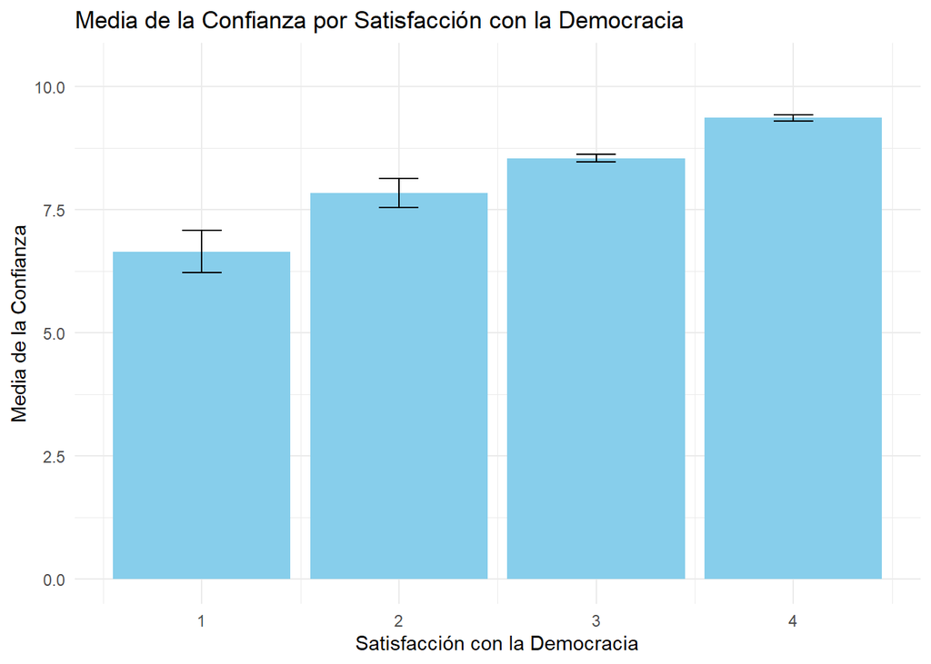

```r
# Gráfico de barras para satisfacción con la democracia
ggplot(df_summary_satis, aes(x = satis_dem, y = mean_confianza)) +
  geom_bar(stat = "identity", fill = "skyblue") +
  geom_errorbar(aes(ymin = mean_confianza - se_confianza, ymax = mean_confianza + se_confianza), width = 0.2) +
  theme_minimal() +
  labs(title = "Media de la Confianza por Satisfacción con la Democracia",
       x = "Satisfacción con la Democracia",
       y = "Media de la Confianza")+scale_y_continuous(limits = c(0, max(df_summary_satis$mean_confianza + df_summary_satis$se_confianza) * 1.1))
```

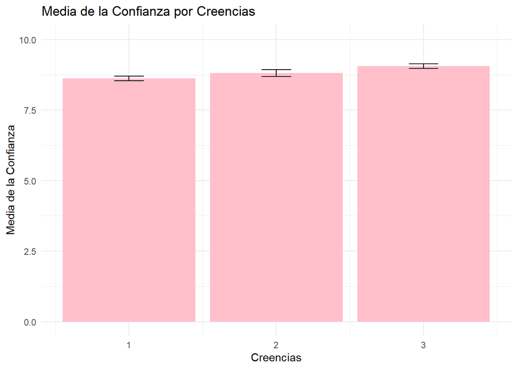

```r
# Gráfico de barras para creencias
ggplot(df_summary_creencias, aes(x = creenciasS, y = mean_confianza)) +
  geom_bar(stat = "identity", fill = "pink") +
  geom_errorbar(aes(ymin = mean_confianza - se_confianza, ymax = mean_confianza + se_confianza), width = 0.2) +
  theme_minimal() +
  labs(title = "Media de la Confianza por Creencias",
       x = "Creencias",
       y = "Media de la Confianza")+scale_y_continuous(limits = c(0, max(df_summary_creencias$mean_confianza + df_summary_creencias$se_confianza) * 1.1))
```

#trataremos a las variable satis_dem como numerica a partir de ahora

```r
class(PERU$satis_dem)
```

```
## [1] "numeric"
```

```r
summary(PERU$satis_dem)
```

```
##    Min. 1st Qu.  Median    Mean 3rd Qu.    Max.
##   1.000   3.000   3.000   3.293   4.000   4.000
```

```r
# hipotesis en R
modelo1=formula(confianza~ satis_dem + creenciasS + etnia + estrato + partido_pol)
```

```r
reg1=lm(modelo1,data=PERU)
```

#LINEALIDAD

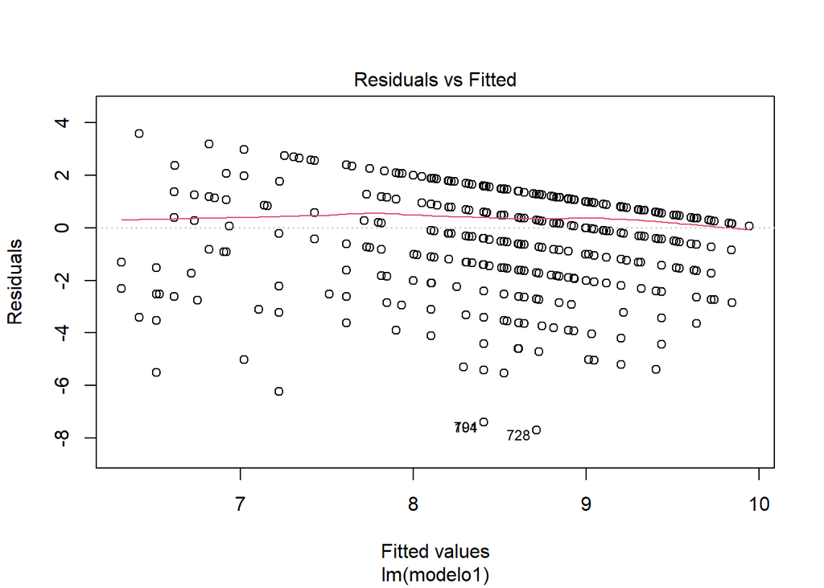

```r
# linea roja debe tender a horizontal
plot(reg1, 1)
```

#HOMOCEDASTICIDAD

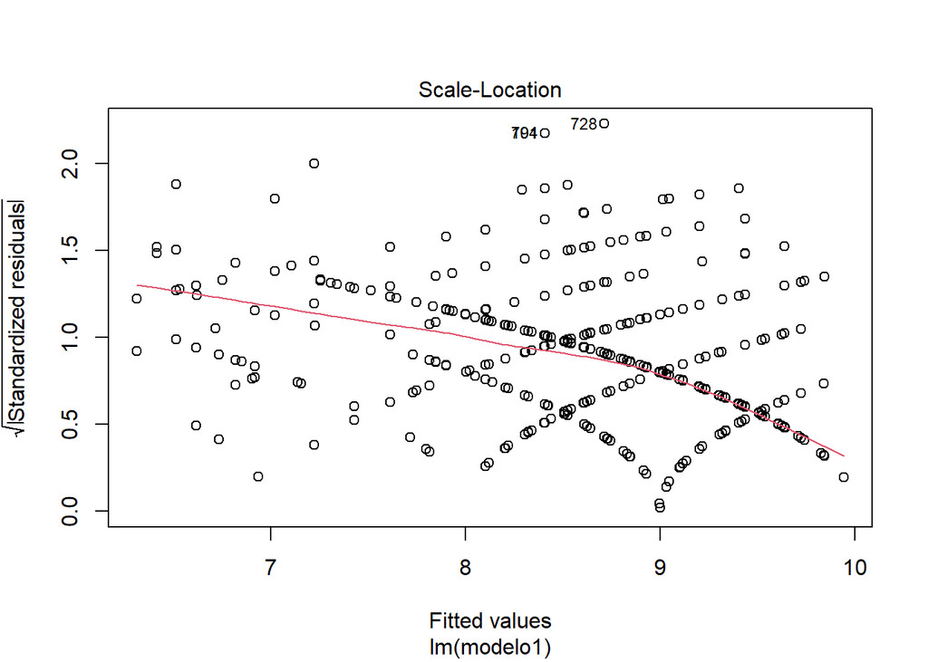

```r
# linea roja debe tender a horizontal
plot(reg1, 3)
```

```r
library(lmtest)
# null: modelo homocedastico
resBP=bptest(reg1)
data.frame(list('BP'=resBP$statistic,
             'df'=resBP$parameter,
             "p-value"=resBP$p.value))
```

```
##          BP df      p.value
## BP 57.79099  5 3.473757e-11
```

#NORMALIDAD DE RESIDUOS

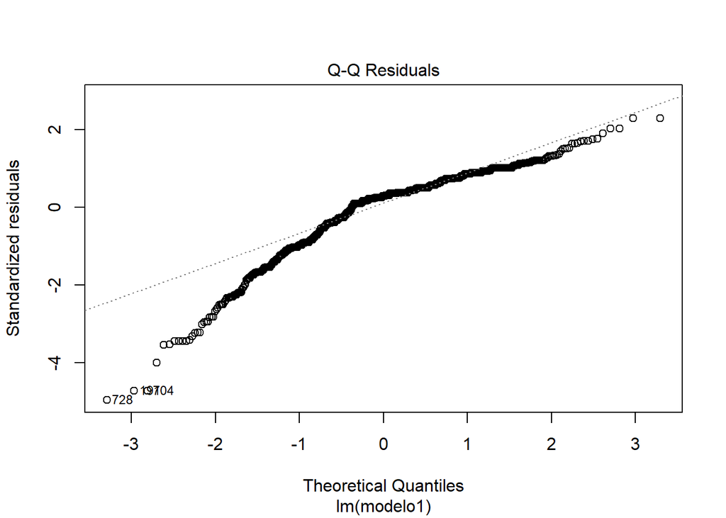

```r
# puntos cerca a la diagonal?
plot(reg1, 2)
```

```r
#NULL: Datos se distribuyen de manera normal
resSW=shapiro.test(reg1$residuals)
data.frame(list('SW'=resSW$statistic,
             "p-value"=resSW$p.value))
```

```
##         SW      p.value
## W 0.898673 3.125903e-25
```

#NO MULTUCOLINEALIDAD

```r
library(DescTools)
# > 5 es problematico
VIF(reg1)
```

```
##   satis_dem  creenciasS       etnia     estrato partido_pol
##    1.032962    1.020213    1.001280    1.012560    1.013156
```

#VALORES INFLUYENTES

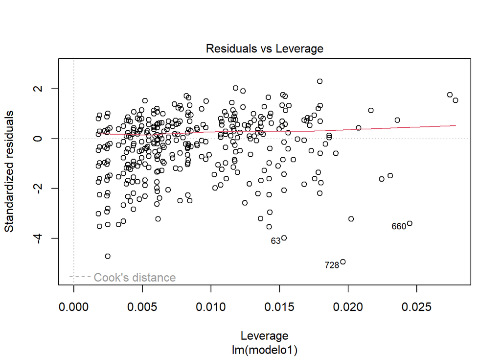

```r
plot(reg1, 5)
```

```r
checkReg2=as.data.frame(influence.measures(reg1)$is.inf)
checkReg2[checkReg2$cook.d & checkReg2$hat,c('cook.d','hat')]
```

```
## [1] cook.d hat
## <0 rows> (or 0-length row.names)
```

Lo que queremos ver en esta regresión es que tanto influyen las variables independientes en la confianza en las instituciones. Entonces tomaremos satis_dem , creenciasS, etnia, estrato, partido_pol

```r
str(PERU)
```

```
## 'data.frame':    1006 obs. of  8 variables:
##  $ numentre   : num  541 904 853 32 854 ...
##  $ satis_dem  : num  3 3 4 4 4 4 3 3 2 4 ...
##  $ creenciasS : num  1 1 2 1 1 1 2 3 1 1 ...
##  $ etnia      : num  4 4 4 3 4 4 3 4 4 4 ...
##  $ estrato    : num  3 3 5 4 5 3 4 4 3 4 ...
##  $ partido_pol: num  0 1 0 0 1 0 0 0 0 1 ...
##  $ confianza  : num  7 7 10 10 10 10 7 6 7 10 ...
##  $ confia     : chr  "1" "1" "1" "1" ...
```

```r
PERU=PERU[complete.cases(PERU),]
```

```r
seleccion=c("creenciasS","etnia","estrato",
            "partido_pol","confia")
PERU[,seleccion]=lapply(PERU[,seleccion],as.factor)
```

```r
peruStats=summary(PERU[,-1])
peruStats
```

```
##    satis_dem     creenciasS etnia   estrato partido_pol   confianza
##  Min.   :1.000   1:542      2: 29   1: 22   0:816       Min.   : 1.000
##  1st Qu.:3.000   2:181      3: 77   2: 58   1:190       1st Qu.: 8.000
##  Median :3.000   3:283      4:839   3:427               Median :10.000
##  Mean   :3.293              6: 61   4:329               Mean   : 8.785
##  3rd Qu.:4.000                      5:170               3rd Qu.:10.000
##  Max.   :4.000                                          Max.   :10.000
##  confia
##  0: 96
##  1:910
##
##
##
##
```

```r
reg1=lm(modelo1,data=PERU)
summary(reg1)
```

```
##
## Call:
## lm(formula = modelo1, data = PERU)
##
## Residuals:
##     Min      1Q  Median      3Q     Max
## -7.5903 -0.6823  0.4517  0.9760  3.8117
##
## Coefficients:
##              Estimate Std. Error t value Pr(>|t|)
## (Intercept)   5.64602    0.49018  11.518  < 2e-16 ***
## satis_dem     0.79320    0.06966  11.388  < 2e-16 ***
## creenciasS2   0.14221    0.13568   1.048  0.29486
## creenciasS3   0.22783    0.11684   1.950  0.05146 .
## etnia3       -0.04772    0.34555  -0.138  0.89019
## etnia4       -0.25091    0.29844  -0.841  0.40068
## etnia6       -0.37075    0.35589  -1.042  0.29778
## estrato2      0.45590    0.39496   1.154  0.24866
## estrato3      0.64646    0.34549   1.871  0.06162 .
## estrato4      0.77360    0.34856   2.219  0.02668 *
## estrato5      1.04611    0.35833   2.919  0.00359 **
## partido_pol1 -0.30530    0.12812  -2.383  0.01737 *
## ---
## Signif. codes:  0 '***' 0.001 '**' 0.01 '*' 0.05 '.' 0.1 ' ' 1
##
## Residual standard error: 1.575 on 994 degrees of freedom
## Multiple R-squared:  0.157,  Adjusted R-squared:  0.1477
## F-statistic: 16.84 on 11 and 994 DF,  p-value: < 2.2e-16
```

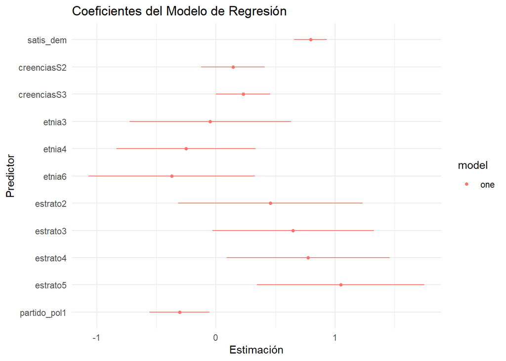

```r
library(ggplot2)
library(broom)
library(dotwhisker)

model_tidy <- tidy(reg1)

dwplot(model_tidy) +
  theme_minimal() +
  labs(title = "Coeficientes del Modelo de Regresión",
       x = "Estimación",
       y = "Predictor")
```

#REGRESIÓN LOGÍSTICA

#DICOTOMIZANDO LA SATISFACCIÓN A SATISFECHO Y NO SATISFECHO

```r
library(dplyr)

# Suponiendo que tu data frame se llama peru_data
PERU <- PERU %>%
  mutate(satisdem_dic = if_else(satis_dem %in% c(3, 4), 1, 0))

# Ver los primeros registros para verificar
head(PERU)
```

```
##   numentre satis_dem creenciasS etnia estrato partido_pol confianza confia
## 1      541         3          1     4       3           0         7      1
## 2      904         3          1     4       3           1         7      1
## 3      853         4          2     4       5           0        10      1
## 4       32         4          1     3       4           0        10      1
## 5      854         4          1     4       5           1        10      1
## 6       94         4          1     4       3           0        10      1
##   satisdem_dic
## 1            1
## 2            1
## 3            1
## 4            1
## 5            1
## 6            1
```

```r
table(PERU$satisdem_dic)
```

```
##
##   0   1
##  83 923
```

```r
PERU$satisdem_dic = factor(PERU$satisdem_dic, levels =c(0:1), labels = c('No está satisfecho', 'Está satisfecho'))
```

```r
table(PERU$satisdem_dic)
```

```
##
## No está satisfecho    Está satisfecho
##                 83                923
```

#DICOTOMIZANDO ESTRATO A CLASE ALTA Y CLASE BAJA Si es Clase Alta = 1 y si es Clase Baja=0

```r
table(PERU$estrato)
```

```
##
##   1   2   3   4   5
##  22  58 427 329 170
```

```r
PERU <- PERU %>%
  mutate(estrato_dic = if_else(estrato %in% c(1,2), 1, 0))
table(PERU$estrato_dic)
```

```
##
##   0   1
## 926  80
```

#DICOTOMIZANDO CREENCIAS Si cree que la democracia es la mejor forma de gobierno será 1 de lo contrario será 0

```r
table(PERU$creenciasS)
```

```
##
##   1   2   3
## 542 181 283
```

```r
PERU <- PERU %>%
  mutate(creencias_dic = if_else(creenciasS %in% c(1), 1, 0))
table(PERU$creencias_dic)
```

```
##
##   0   1
## 464 542
```

```r
PERU$creencias_dic = factor(PERU$creencias_dic, levels =c(0:1), labels = c('No cree', 'Sí cree'))
```

#ETNIA LA DEJAREMOS COMO TAL

```r
table(PERU$etnia)
```

```
##
##   2   3   4   6
##  29  77 839  61
```

```r
PERU$etnia = as.factor(PERU$etnia)
```

```r
library(tidyverse)
library(car)
```

#CORRELACION ENTRE LAS VARIABLES

#HAREMOS CHI CUADRADO

```r
# Convertir las variables a factores
PERU$confia <- as.factor(PERU$confia)
PERU$satisdem_dic <- as.factor(PERU$satisdem_dic)
PERU$creencias_dic <- as.factor(PERU$creencias_dic)

# Tabla de contingencia y prueba de Chi-cuadrado para satisfacción con la democracia
tabla_satisfaccion <- table(PERU$satisdem_dic,PERU$confia)
chi_satisfaccion <- chisq.test(tabla_satisfaccion)
chi_satisfaccion
```

```
##
##  Pearson's Chi-squared test with Yates' continuity correction
##
## data:  tabla_satisfaccion
## X-squared = 58.318, df = 1, p-value = 2.229e-14
```

```r
# Tabla de contingencia y prueba de Chi-cuadrado para creencias
tabla_creencias <- table(PERU$creencias_dic, PERU$confia)
chi_creencias <- chisq.test(tabla_creencias)
chi_creencias
```

```
##
##  Pearson's Chi-squared test with Yates' continuity correction
##
## data:  tabla_creencias
## X-squared = 6.4288, df = 1, p-value = 0.01123
```

```r
# Resultados para satisfacción con la democracia
print(chi_satisfaccion)
```

```
##
##  Pearson's Chi-squared test with Yates' continuity correction
##
## data:  tabla_satisfaccion
## X-squared = 58.318, df = 1, p-value = 2.229e-14
```

```r
# Resultados para creencias
print(chi_creencias)
```

```
##
##  Pearson's Chi-squared test with Yates' continuity correction
##
## data:  tabla_creencias
## X-squared = 6.4288, df = 1, p-value = 0.01123
```

Interptetamos -> Rechazamos la hipótesis nula (No hay asociación) y concluimos que existe una asociación significativa entre las variables. GRAFICAMOS…

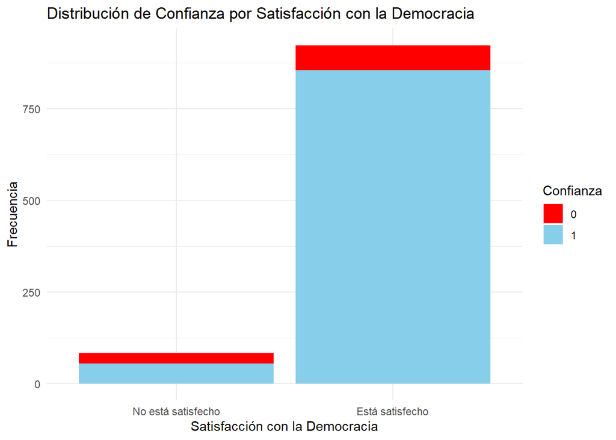

```r
# Convertir tabla de contingencia en un dataframe
df_satis_dem <- as.data.frame(tabla_satisfaccion)
colnames(df_satis_dem) <- c("Satisfaccion", "Confianza", "Frecuencia")

# Gráfico de barras apiladas
ggplot(df_satis_dem, aes(x = Satisfaccion, y = Frecuencia, fill = Confianza)) +
  geom_bar(stat = "identity") +
  theme_minimal() +
  labs(title = "Distribución de Confianza por Satisfacción con la Democracia",
       x = "Satisfacción con la Democracia",
       y = "Frecuencia") +
  scale_fill_manual(values = c("red", "skyblue")) # Ajustar colores si es necesario
```

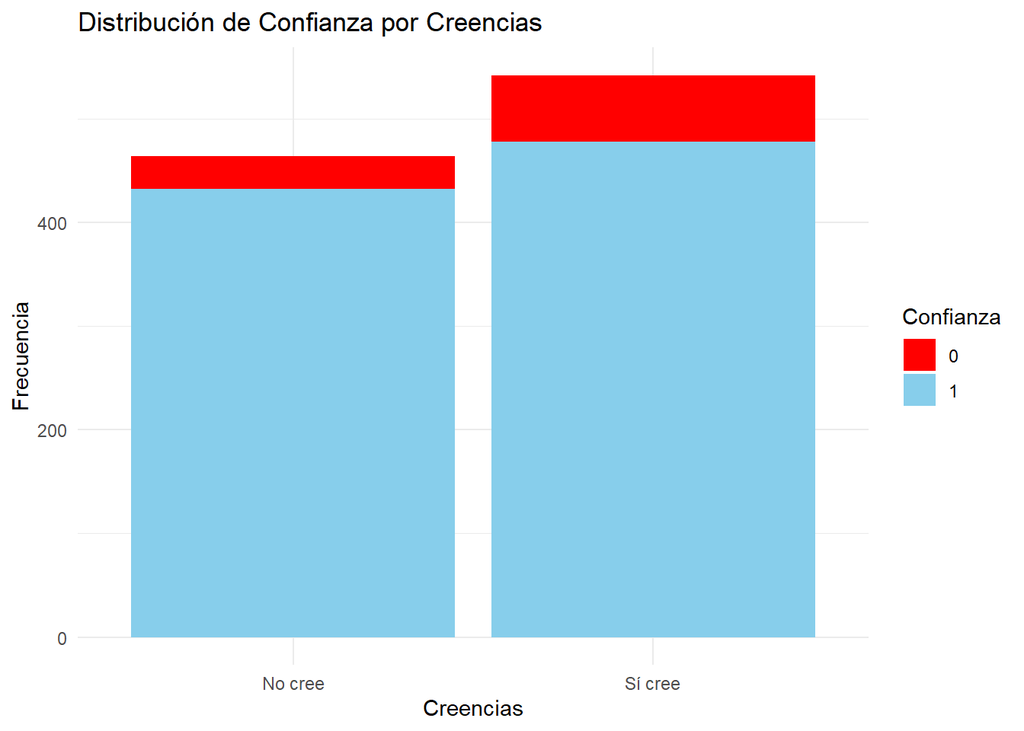

```r
# Convertir tabla de contingencia en un dataframe
df_creencias <- as.data.frame(tabla_creencias)
colnames(df_creencias) <- c("Creencias", "Confianza", "Frecuencia")

# Gráfico de barras apiladas
ggplot(df_creencias, aes(x = Creencias, y = Frecuencia, fill = Confianza)) +
  geom_bar(stat = "identity") +
  theme_minimal() +
  labs(title = "Distribución de Confianza por Creencias",
       x = "Creencias",
       y = "Frecuencia") +
  scale_fill_manual(values = c("red", "skyblue")) # Ajustar colores si es necesario
```

```r
library(car)
modelo <- glm(confia ~ satisdem_dic + creencias_dic + estrato_dic + partido_pol + etnia,
              data = PERU, family = binomial)

# Resumen del modelo
summary(modelo)
```

```
##
## Call:
## glm(formula = confia ~ satisdem_dic + creencias_dic + estrato_dic +
##     partido_pol + etnia, family = binomial, data = PERU)
##
## Coefficients:
##                             Estimate Std. Error z value Pr(>|z|)
## (Intercept)                  1.28926    0.70961   1.817   0.0692 .
## satisdem_dicEstá satisfecho  1.74946    0.27164   6.440 1.19e-10 ***
## creencias_dicSí cree        -0.51558    0.23513  -2.193   0.0283 *
## estrato_dic                 -0.37807    0.35136  -1.076   0.2819
## partido_pol1                -0.44057    0.25622  -1.720   0.0855 .
## etnia3                       0.82849    0.88494   0.936   0.3492
## etnia4                      -0.08836    0.65895  -0.134   0.8933
## etnia6                      -0.62450    0.74287  -0.841   0.4005
## ---
## Signif. codes:  0 '***' 0.001 '**' 0.01 '*' 0.05 '.' 0.1 ' ' 1
##
## (Dispersion parameter for binomial family taken to be 1)
##
##     Null deviance: 633.62  on 1005  degrees of freedom
## Residual deviance: 576.68  on  998  degrees of freedom
## AIC: 592.68
##
## Number of Fisher Scoring iterations: 6
```

```r
exp(coef(modelo))
```

```
##                 (Intercept) satisdem_dicEstá satisfecho
##                   3.6300860                   5.7515002
##        creencias_dicSí cree                 estrato_dic
##                   0.5971561                   0.6851843
##                partido_pol1                      etnia3
##                   0.6436711                   2.2898589
##                      etnia4                      etnia6
##                   0.9154348                   0.5355268
```

#PARA LA ETNIA

```r
dep=PERU$confia # a la fila
ind=PERU$etnia # a la columna

volsexTable=table(dep,ind,dnn = c('confia','etnia'))
library(kableExtra)
### suma por fila y columna
addmargins(volsexTable)%>%
    kable(caption = "Tabla de Contingencia: 'Confía' y 'Etnia'")%>%
    kableExtra::kable_styling(full_width = F)
```

Tabla de Contingencia: ‘Confía’ y ‘Etnia’

|  | 2 | 3 | 4 | 6 | Sum |
| --- | --- | --- | --- | --- | --- |
| 0 | 3 | 3 | 80 | 10 | 96 |
| 1 | 26 | 74 | 759 | 51 | 910 |
| Sum | 29 | 77 | 839 | 61 | 1006 |

2: BLACK 3: INDIGENOUS 4: MESTIZO 6: WHITE

#EFECTOS MARGINALES

```r
library(margins)
library(kableExtra)
marginalsData=summary(margins(modelo))
marginalsData%>% kable(caption = "Efectos Marginales Promedio (AME)") %>%kableExtra::kable_styling(full_width = T)
```

Efectos Marginales Promedio (AME)

| factor | AME | SE | z | p | lower | upper |
| --- | --- | --- | --- | --- | --- | --- |
| creencias_dicSí cree | -0.0399902 | 0.0177454 | -2.2535533 | 0.0242243 | -0.0747705 | -0.0052099 |
| estrato_dic | -0.0300457 | 0.0279291 | -1.0757842 | 0.2820238 | -0.0847858 | 0.0246944 |
| etnia3 | 0.0462369 | 0.0543686 | 0.8504334 | 0.3950842 | -0.0603237 | 0.1527975 |
| etnia4 | -0.0068898 | 0.0498555 | -0.1381959 | 0.8900856 | -0.1046048 | 0.0908251 |
| etnia6 | -0.0591058 | 0.0645573 | -0.9155552 | 0.3599002 | -0.1856357 | 0.0674242 |
| partido_pol1 | -0.0384315 | 0.0243821 | -1.5762134 | 0.1149766 | -0.0862196 | 0.0093567 |
| satisdem_dicEstá satisfecho | 0.2328349 | 0.0503720 | 4.6223065 | 0.0000038 | 0.1341075 | 0.3315622 |

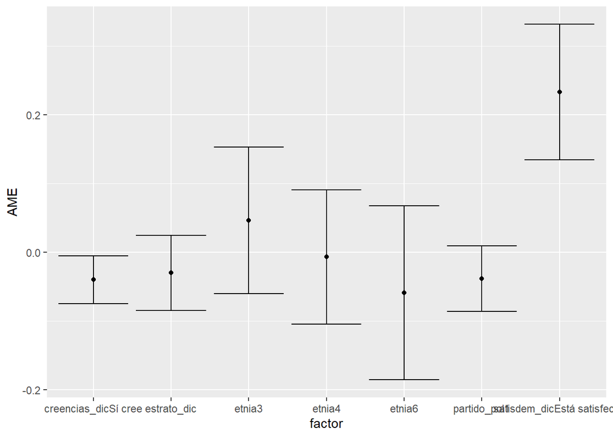

```r
library(ggplot2)
base= ggplot(marginalsData,aes(x=factor, y=AME)) + geom_point()
base +  geom_errorbar(aes(ymin=lower, ymax=upper))
```

#SI EL COVARIADO INCLUYE A CERO NO SERÁ SIGNIFICATIVO

```r
names(PERU)
```

```
##  [1] "numentre"      "satis_dem"     "creenciasS"    "etnia"
##  [5] "estrato"       "partido_pol"   "confianza"     "confia"
##  [9] "satisdem_dic"  "estrato_dic"   "creencias_dic"
```

```r
# Instalar y cargar la librería writexl si aún no lo has hecho
# install.packages("writexl")
library(writexl)

# Seleccionar las columnas deseadas
Last <- PERU[, c("numentre", "satis_dem", "creenciasS", "etnia", "estrato", "partido_pol", "confianza", "confia", "satisdem_dic", "estrato_dic", "creencias_dic")]

# Guardar el dataframe en un archivo Excel
write_xlsx(Last, path = "C:/Trabajo grupal Tucaloza y Valentini/F00017014-Latinobarometro_2023_Rdata_v1_0.xlsx")
```